# hw2

### 3.2.3 Explain the difference between the two 95% CI’s

The reason why the two 95% CI’s differ is that, `year` is correlated with new variable `horsepower`. More specifically, they are negatively correlated according to the correlation matrix. Therefore, when `year` is the only explanatory variable, its coefficient estimate will absorb part of the effect of `horsepower` (this is an example of violation of necessary assumptions to derive unbiased estimate in regression models). In this case `horsepower` is negatively correlated with `mpg` and also negatively correlated with `year`. Therefore, when it is not included in the model, the estimate of the coefficient, as well as the confidence interval for `year`, is biased upward.

### 3.2.4 Model 3: `MPG ~ Year * Horsepower`

```r
fit3 <- lm(mpg ~ year*horsepower, Auto)
stargazer::stargazer(fit3, type=output_format, align=TRUE)
```

|  | *Dependent variable:* |
| --- | --- |
|  | mpg |
| year | 2.190*** |
|  | (0.161) |
| horsepower | 1.050*** |
|  | (0.115) |
| year:horsepower | -0.016*** |
|  | (0.002) |
| Constant | -127.000*** |
|  | (12.100) |
| Observations | 392 |
| R<sup>2</sup> | 0.752 |
| Adjusted R<sup>2</sup> | 0.750 |
| Residual Std. Error | 3.900 (df = 388) |
| F Statistic | 393.000*** (df = 3; 388) |
| *Note:* | p<0.1; p<0.05; p<0.01 |

```r
anova(fit3)
```

```
## Analysis of Variance Table
##
## Response: mpg
##                  Df Sum Sq Mean Sq F value Pr(>F)
## year              1   8028    8028     528 <2e-16 ***
## horsepower        1   8300    8300     546 <2e-16 ***
## year:horsepower   1   1588    1588     104 <2e-16 ***
## Residuals       388   5903      15
## ---
## Signif. codes:  0 '***' 0.001 '**' 0.01 '*' 0.05 '.' 0.1 ' ' 1
```

The interaction effect is significant at .05 level.

`Year` effect: When year increases by 1 unit, we expect, on average the mpg will increase about 2.19.

## 3.3 Categorical predictors

### 3.3.1 `cylinders` as a continuous/numeric variable

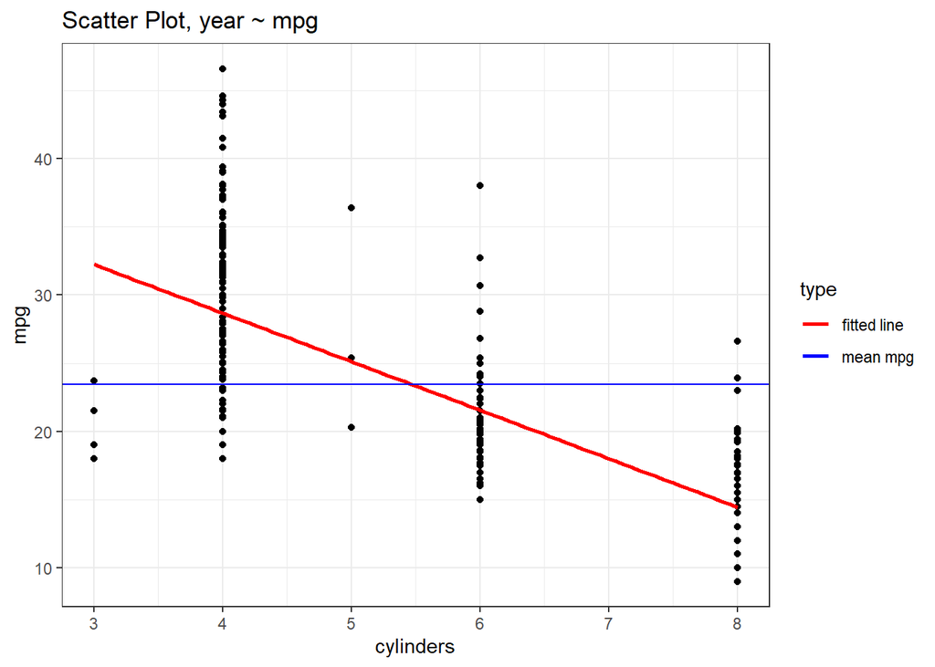

```r
fit4 <- lm(mpg ~ cylinders, data = Auto)
ggplot(Auto, aes(x = cylinders , y = mpg)) +
  geom_point() +
  geom_smooth(aes(color = "fitted line"),method="lm",se=F) +
  geom_hline(aes(yintercept = mean(mpg), color = "mean mpg")) +
  scale_colour_manual(name = "type",values = c("red","blue"))+
  labs(title = "Scatter Plot, year ~ mpg") +
  theme_bw()
```

```r
stargazer::stargazer(fit4, type=output_format, align=TRUE)
```

|  | *Dependent variable:* |
| --- | --- |
|  | mpg |
| cylinders | -3.560*** |
|  | (0.146) |
| Constant | 42.900*** |
|  | (0.835) |
| Observations | 392 |
| R<sup>2</sup> | 0.605 |
| Adjusted R<sup>2</sup> | 0.604 |
| Residual Std. Error | 4.910 (df = 390) |
| F Statistic | 597.000*** (df = 1; 390) |
| *Note:* | p<0.1; p<0.05; p<0.01 |

Cylinders is significant at the 0.01 level; however, the correlation between cylinders and mpg is not linear.

`Cylinders` effect: When number of cylinders increases by 1, we expect, on average the mpg will decrease about -3.558.

### 3.3.2 `cylinders` as a categorical/factor

```r
Auto1<-Auto
Auto1$cylinders<-as.factor(Auto1$cylinders)
levels(Auto1$cylinders)
```

```
## [1] "3" "4" "5" "6" "8"
```

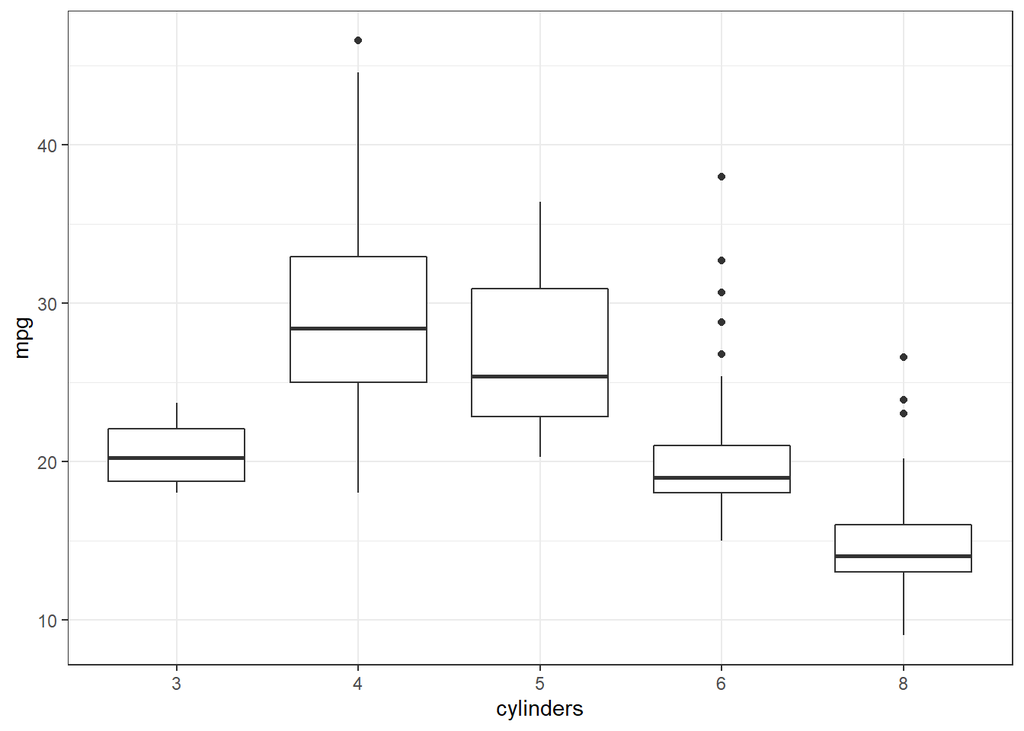

```r
ggplot(Auto1) + geom_boxplot(aes(x = cylinders, y = mpg)) + theme_bw()
```

Our model is:

$$y_{i|x=3} = \mu_{3} + \epsilon_i$$
$$y_{i|x=4} = \mu_{4} + \epsilon_i$$
$$y_{i|x=5} = \mu_{5} + \epsilon_i$$
$$y_{i|x=6} = \mu_{6} + \epsilon_i$$
$$y_{i|x=8} = \mu_{8} + \epsilon_i$$

where $\mu_{3}$, $\mu_{4}$, $\mu_{5}$, $\mu_{6}$, $\mu_{8}$ are the mean MPG of each level of cylinders and $\epsilon \sim \mathcal{N}(0,\sigma^2)$. We want to compare the five means and this can be done through linear model with indicator functions.

We are interested in the following hypotheses:

$$H_0: \mu_{3} = \mu_{4} = \mu_{5} = \mu_{6} = \mu_{8}$$

Let `3 cylinders` as the benchmark. The above Anova model is same as

$$y_i = \beta_{3} + \beta_{4} I\{Cylinders = 4\} + \beta_5 I\{Cylinders = 5\} + \beta_6 I\{Cylinders = 6\} + \beta_8 I\{Cylinders = 8\} + \epsilon_i$$
where * $\beta_{3} = \textbf{E}(MPG|3)$

- $\beta_{4} = \textbf{E}(MPG|4)-\textbf{E}(MPG|3)$: the increment between 4 cylinders and 3 cylinders
- $\beta_5 = \textbf{E}(MPG|5)-\textbf{E}(MPG|3)$: the increment between 5 cylinders and 3 cylinders
- $\beta_6 = \textbf{E}(MPG|6)-\textbf{E}(MPG|3)$: the increment between 6 cylinders and 3 cylinders
- $\beta_8 = \textbf{E}(MPG|8)-\textbf{E}(MPG|3)$: the increment between 8 cylinders and 3 cylinders

To test
$$H_0: \mu_{3} = \mu_{4} = \mu_{5} = \mu_{6} = \mu_{8}$$
is same as to test
$$H_0: \beta_{4} = \beta_{5} = \beta_{6} = \beta_{8} = 0$$

Now we can use `lm()` to fit the model and carry out the tests:

```r
fit5 <- lm(mpg ~ cylinders, Auto1)
stargazer::stargazer(fit5, type=output_format, align=TRUE)
```

|  | *Dependent variable:* |
| --- | --- |
|  | mpg |
| cylinders4 | 8.730*** |
|  | (2.370) |
| cylinders5 | 6.820* |
|  | (3.590) |
| cylinders6 | -0.577 |
|  | (2.400) |
| cylinders8 | -5.590** |
|  | (2.400) |
| Constant | 20.600*** |
|  | (2.350) |
| Observations | 392 |
| R<sup>2</sup> | 0.641 |
| Adjusted R<sup>2</sup> | 0.638 |
| Residual Std. Error | 4.700 (df = 387) |
| F Statistic | 173.000*** (df = 4; 387) |
| *Note:* | p<0.1; p<0.05; p<0.01 |

Cylinders is significant at the .01 level.

`Cylinders` effect: We expect, on average the mpg with 3 cylinders will be 20.550, the mpg with 4 cylinders will increase 8.734 compared to the mpg with 3 cylinders, the mpg with 5 cylinders will increase 6.817 compared to the mpg with 3 cylinders, the mpg with 6 cylinders will decrease 0.577 compared to the mpg with 3 cylinders, the mpg with 8 cylinders will decrease 5.587 compared to the mpg with 3 cylinders. Autos with 4 cylinders have the largest mpg. Autos with 8 cylinders have the smallest mpg.

### 3.3.3 Fundamental differences

The fundamental difference between the above two methods is: when we treat cylinders as a continuous variable, we assume that its correlation with mpg is linear, i.e., a certain difference in the number of cylinders predicts a certain difference in mpg, no matter it is from 5 to 6 or from 7 to 8; when we treat cylinders as a factor, we instead assume that relative to a benchmark, every specific number of cylinders predicts a specific difference in mpg. We discard the linearity assumption in the latter case; in fact, we treat them as several different binary variables.

### 3.3.4 Test the null hypothesis

```r
anova(fit4,fit5)
```

```
## Analysis of Variance Table
##
## Model 1: mpg ~ cylinders
## Model 2: mpg ~ cylinders
##   Res.Df  RSS Df Sum of Sq    F  Pr(>F)
## 1    390 9416
## 2    387 8544  3       871 13.2 3.4e-08 ***
## ---
## Signif. codes:  0 '***' 0.001 '**' 0.01 '*' 0.05 '.' 0.1 ' ' 1
```

We reject the null hypothesis with a p-value much smaller than 0.01. This indicates mpg relates to cylinders as a categorical variable; or equivalently, the relationship between cylinders and mpg is nonlinear.

## 3.4 Results

### 3.4.1 Describe one model: use mpg; take reciprocal of horsepower, displacement and weight

From the scatter plots presented above, we see that taking reciprocal of displacement, weight and horsepower fits the linearity assumption better. Therefore, our final model will consider the transformed ones instead of the original ones.

```r
Auto.new1 = data.table(Auto.new1)
Auto.new2 = data.table(Auto.new2)
```

We include explanatory variables one by one in a stepwise forward manner; when the p-value of the LR test for the new model against the model in the last step is larger than 0.05, we stop the process and get a model output.

**Forward stepwise selection**

```r
# stepwise forwarding
for.onestage = function(data1,data2,yname = colnames(data1)[1]){
  y = unlist(subset(data1,select = yname))
  cov = subset(data1,select = -get(yname))
  base =  lm(y~.,data = cov)
  new = list()
  lr = matrix(nrow = ncol(data2))
  for (i in 1:ncol(data2)) {
    new[[i]] = lm(y~.+data2[[i]],
                   data = cov)
    lr[i] = lrtest(base,new[[i]])[2,5]
  }
  loc = which.min(lr)
  if(lr[loc]<0.05){
    return(list(colnames(data2[,loc,with=F]),lr[loc]))
  }else{
    return('Stop searching')
  }
}

# linear terms

reg.current = Auto.new1[,.(
  mpg,
  year,
  cylinders
)] # initial covariance matrix
cov.rest = Auto.new1[,.(
  displacement.rec,
  horsepower.rec,
  weight.rec,
  acceleration,
  origin
)]

i = 0
while(i<1){
  new.va = for.onestage(reg.current,cov.rest)
  print(new.va)
  if(new.va[[1]] == 'Stop searching'){
    break
  }
  reg.current[,(new.va[[1]]) := cov.rest[,new.va[[1]],with=F]]
  cov.rest = cov.rest[,(new.va[[1]]) := NULL]
}
```

```
## [[1]]
## [1] "weight.rec"
##
## [[2]]
## [1] 7.88e-51
##
## [[1]]
## [1] "horsepower.rec"
##
## [[2]]
## [1] 6.1e-05
##
## [[1]]
## [1] "acceleration"
##
## [[2]]
## [1] 0.00555
##
## [[1]]
## [1] "origin"
##
## [[2]]
## [1] 0.0032
##
## [1] "Stop searching"
```

We include the reciprocal of weight, the reciprocal of horsepower, acceleration and origin sequentially, in addition to year and cylinders. Next we are going to examine the output model.

**Final determination of models in this group**

```r
fit.prefinal = lm(mpg~.,reg.current)
stargazer(fit.prefinal,type=output_format, align=TRUE)
```

|  | *Dependent variable:* |
| --- | --- |
|  | mpg |
| year | 0.740*** |
|  | (0.044) |
| cylinders4 | 6.560*** |
|  | (1.480) |
| cylinders5 | 7.880*** |
|  | (2.270) |
| cylinders6 | 4.650*** |
|  | (1.530) |
| cylinders8 | 4.870*** |
|  | (1.570) |
| weight.rec | 30,713.000*** |
|  | (4,703.000) |
| horsepower.rec | 668.000*** |
|  | (128.000) |
| acceleration | -0.280*** |
|  | (0.092) |
| origin2 | 0.758 |
|  | (0.478) |
| origin3 | 1.600*** |
|  | (0.475) |
| Constant | -52.900*** |
|  | (4.230) |
| Observations | 392 |
| R<sup>2</sup> | 0.871 |
| Adjusted R<sup>2</sup> | 0.867 |
| Residual Std. Error | 2.840 (df = 381) |
| F Statistic | 257.000*** (df = 10; 381) |
| *Note:* | p<0.1; p<0.05; p<0.01 |

```r
# try an interaction term
fit.final1<-lm(mpg~.+year:horsepower.rec,reg.current)
stargazer(fit.final1,type=output_format, align=TRUE)
```

|  | *Dependent variable:* |
| --- | --- |
|  | mpg |
| year | -0.171 |
|  | (0.136) |
| cylinders4 | 5.840*** |
|  | (1.400) |
| cylinders5 | 6.880*** |
|  | (2.140) |
| cylinders6 | 4.440*** |
|  | (1.440) |
| cylinders8 | 3.920*** |
|  | (1.490) |
| weight.rec | 35,748.000*** |
|  | (4,487.000) |
| horsepower.rec | -5,777.000*** |
|  | (924.000) |
| acceleration | -0.154* |
|  | (0.088) |
| origin2 | 0.966** |
|  | (0.452) |
| origin3 | 1.270*** |
|  | (0.450) |
| year:horsepower.rec | 82.900*** |
|  | (11.800) |
| Constant | 14.400 |
|  | (10.400) |
| Observations | 392 |
| R<sup>2</sup> | 0.886 |
| Adjusted R<sup>2</sup> | 0.882 |
| Residual Std. Error | 2.680 (df = 380) |
| F Statistic | 268.000*** (df = 11; 380) |
| *Note:* | p<0.1; p<0.05; p<0.01 |

```r
fit.final2<-lm(mpg~cylinders+horsepower.rec+weight.rec+acceleration+year:horsepower.rec+origin,reg.current)
stargazer(fit.final2,type=output_format, align=TRUE)
```

|  | *Dependent variable:* |
| --- | --- |
|  | mpg |
| cylinders4 | 5.930*** |
|  | (1.400) |
| cylinders5 | 7.000*** |
|  | (2.140) |
| cylinders6 | 4.480*** |
|  | (1.440) |
| cylinders8 | 4.120*** |
|  | (1.480) |
| horsepower.rec | -4,693.000*** |
|  | (328.000) |
| weight.rec | 35,256.000*** |
|  | (4,473.000) |
| acceleration | -0.173** |
|  | (0.087) |
| origin2 | 0.963** |
|  | (0.452) |
| origin3 | 1.310*** |
|  | (0.449) |
| horsepower.rec:year | 68.800*** |
|  | (3.620) |
| Constant | 1.700 |
|  | (2.190) |
| Observations | 392 |
| R<sup>2</sup> | 0.885 |
| Adjusted R<sup>2</sup> | 0.882 |
| Residual Std. Error | 2.680 (df = 381) |
| F Statistic | 294.000*** (df = 10; 381) |
| *Note:* | p<0.1; p<0.05; p<0.01 |

```r
anova(fit.final1,fit.final2) # The inclusion of year is not necessary.
```

```
## Analysis of Variance Table
##
## Model 1: mpg ~ year + cylinders + weight.rec + horsepower.rec + acceleration +
##     origin + year:horsepower.rec
## Model 2: mpg ~ cylinders + horsepower.rec + weight.rec + acceleration +
##     year:horsepower.rec + origin
##   Res.Df  RSS Df Sum of Sq    F Pr(>F)
## 1    380 2723
## 2    381 2734 -1     -11.3 1.58   0.21
```

We choose fit.final2 in this group.

```r
fit.final = fit.final2
```

**Diagnosis**

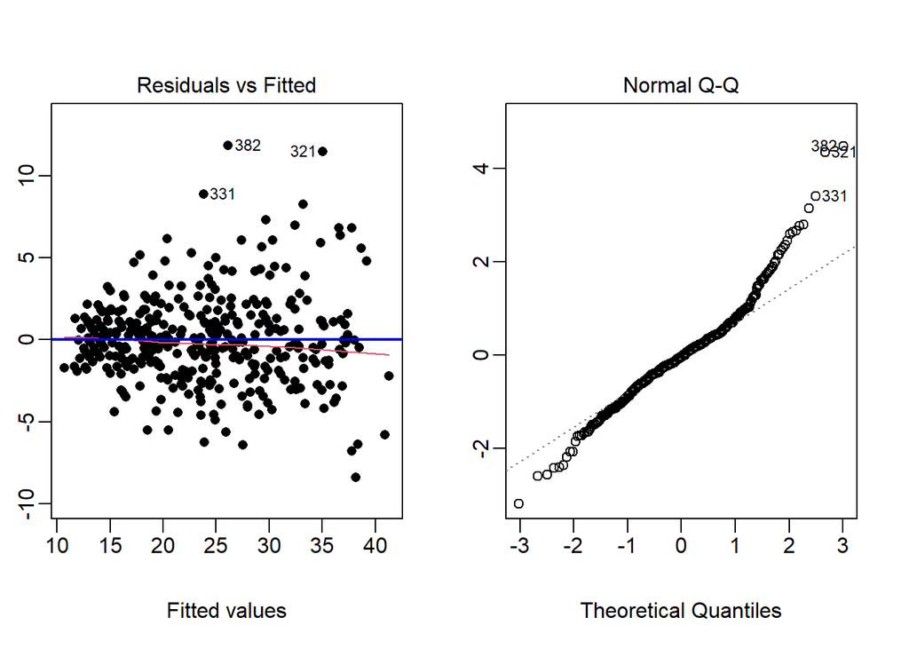

```r
par(mfrow=c(1,2), mar=c(5,2,4,2), mgp=c(3,0.5,0))
plot(fit.final, 1, pch=16) # residual plot
abline(h=0, col="blue", lwd=2)
plot(fit.final, 2) # qqplot
```

The residual plot casts some doubt on the homoscedasticity assumption. There is a trend that variance increases with the fitted values. Therefore, correcting the bias with a heteroscedasticity-robust standard error is preferred.

The QQ plots indicates that the residuals have a thicker tail than the normal distribution.

**Prediction**

```r
new <- data.frame(cylinders="8",displacement.rec=1/350,horsepower.rec=1/260,weight.rec=1/4000,year=83,origin="1",acceleration = mean(Auto.new$acceleration)) # impute acceleration
CIpred <- predict(fit.final, new, interval="prediction", se.fit=TRUE)
CIpred
```

```
## $fit
##    fit  lwr  upr
## 1 15.9 10.5 21.3
##
## $se.fit
## [1] 0.631
##
## $df
## [1] 381
##
## $residual.scale
## [1] 2.68
```

### 3.4.2 Alternative: use log.mpg; no reciprocals

```r
# try to use log(mpg)
reg.current = Auto.new2[,.(
  log.mpg,
  year,
  cylinders
)] # initial covariance matrix
cov.rest = Auto.new2[,.(
  displacement,
  horsepower,
  weight,
  acceleration,
  origin
)]
```

**Forward stepwise selection**

```r
i = 0
while(i<1){
  new.va = for.onestage(reg.current,cov.rest)
  print(new.va)
  if(new.va[[1]] == 'Stop searching'){
    break
  }
  reg.current[,(new.va[[1]]) := cov.rest[,new.va[[1]],with=F]]
  cov.rest = cov.rest[,(new.va[[1]]) := NULL]
}
```

```
## [[1]]
## [1] "weight"
##
## [[2]]
## [1] 5.86e-49
##
## [[1]]
## [1] "horsepower"
##
## [[2]]
## [1] 0.0015
##
## [[1]]
## [1] "origin"
##
## [[2]]
## [1] 0.00191
##
## [[1]]
## [1] "displacement"
##
## [[2]]
## [1] 0.0134
##
## [1] "Stop searching"
```

**Final determination of models in this group**

```r
# final model
fit.prefinal = lm(log.mpg~.,reg.current)
stargazer(fit.prefinal,type=output_format, align=TRUE)
```

|  | *Dependent variable:* |
| --- | --- |
|  | log.mpg |
| year | 0.029*** |
|  | (0.002) |
| cylinders4 | 0.249*** |
|  | (0.059) |
| cylinders5 | 0.279*** |
|  | (0.091) |
| cylinders6 | 0.126* |
|  | (0.066) |
| cylinders8 | 0.140* |
|  | (0.076) |
| weight | -0.0002*** |
|  | (0.00002) |
| horsepower | -0.002*** |
|  | (0.0004) |
| origin2 | 0.058*** |
|  | (0.020) |
| origin3 | 0.077*** |
|  | (0.019) |
| displacement | 0.001** |
|  | (0.0003) |
| Constant | 1.430*** |
|  | (0.154) |
| Observations | 392 |
| R<sup>2</sup> | 0.894 |
| Adjusted R<sup>2</sup> | 0.891 |
| Residual Std. Error | 0.112 (df = 381) |
| F Statistic | 320.000*** (df = 10; 381) |
| *Note:* | p<0.1; p<0.05; p<0.01 |

```r
# try an interaction term
fit.final1<-lm(log.mpg~.+year:horsepower,reg.current)
stargazer(fit.final1,type=output_format, align=TRUE)
```

|  | *Dependent variable:* |
| --- | --- |
|  | log.mpg |
| year | 0.045*** |
|  | (0.005) |
| cylinders4 | 0.237*** |
|  | (0.059) |
| cylinders5 | 0.262*** |
|  | (0.090) |
| cylinders6 | 0.139** |
|  | (0.065) |
| cylinders8 | 0.161** |
|  | (0.076) |
| weight | -0.0002*** |
|  | (0.00002) |
| horsepower | 0.010*** |
|  | (0.004) |
| origin2 | 0.058*** |
|  | (0.020) |
| origin3 | 0.071*** |
|  | (0.019) |
| displacement | 0.0005* |
|  | (0.0003) |
| year:horsepower | -0.0002*** |
|  | (0.00005) |
| Constant | 0.287 |
|  | (0.371) |
| Observations | 392 |
| R<sup>2</sup> | 0.897 |
| Adjusted R<sup>2</sup> | 0.894 |
| Residual Std. Error | 0.111 (df = 380) |
| F Statistic | 300.000*** (df = 11; 380) |
| *Note:* | p<0.1; p<0.05; p<0.01 |

```r
fit.final2<-lm(log.mpg~cylinders+weight+year*horsepower+origin,reg.current)
stargazer(fit.final2,type=output_format, align=TRUE)
```

|  | *Dependent variable:* |
| --- | --- |
|  | log.mpg |
| cylinders4 | 0.257*** |
|  | (0.058) |
| cylinders5 | 0.289*** |
|  | (0.089) |
| cylinders6 | 0.184*** |
|  | (0.060) |
| cylinders8 | 0.231*** |
|  | (0.064) |
| weight | -0.0002*** |
|  | (0.00002) |
| year | 0.046*** |
|  | (0.005) |
| horsepower | 0.012*** |
|  | (0.003) |
| origin2 | 0.046** |
|  | (0.019) |
| origin3 | 0.061*** |
|  | (0.018) |
| year:horsepower | -0.0002*** |
|  | (0.00005) |
| Constant | 0.170 |
|  | (0.366) |
| Observations | 392 |
| R<sup>2</sup> | 0.896 |
| Adjusted R<sup>2</sup> | 0.893 |
| Residual Std. Error | 0.111 (df = 381) |
| F Statistic | 328.000*** (df = 10; 381) |
| *Note:* | p<0.1; p<0.05; p<0.01 |

```r
anova(fit.final1,fit.final2) # The inclusion of displacement is not necessary; only significant at 10%.
```

```
## Analysis of Variance Table
##
## Model 1: log.mpg ~ year + cylinders + weight + horsepower + origin + displacement +
##     year:horsepower
## Model 2: log.mpg ~ cylinders + weight + year * horsepower + origin
##   Res.Df  RSS Df Sum of Sq  F Pr(>F)
## 1    380 4.67
## 2    381 4.71 -1   -0.0368  3  0.084 .
## ---
## Signif. codes:  0 '***' 0.001 '**' 0.01 '*' 0.05 '.' 0.1 ' ' 1
```

```r
fit.final = fit.final2
```

**Diagnosis**

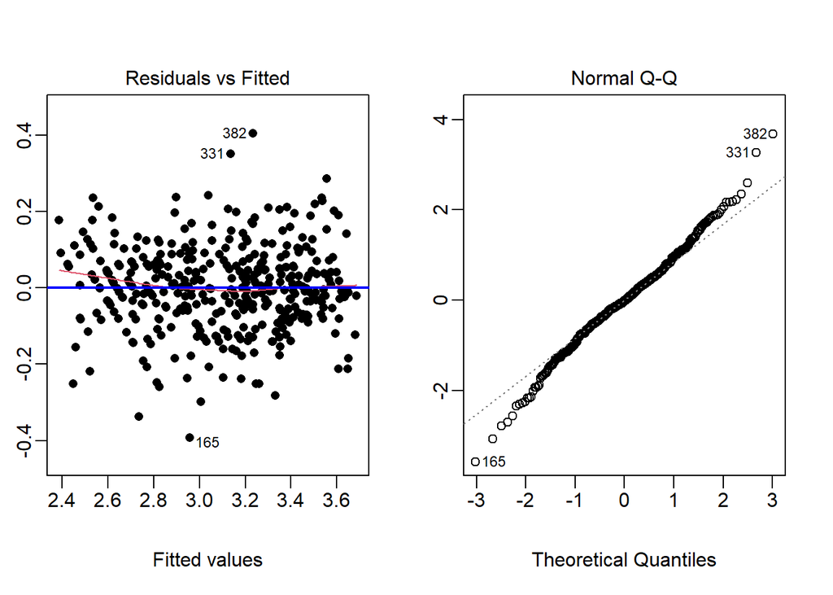

```r
# diagnosis
?Auto
par(mfrow=c(1,2), mar=c(5,2,4,2), mgp=c(3,0.5,0))
plot(fit.final, 1, pch=16) # residual plot; the heteroscedasticity concern is well handled
abline(h=0, col="blue", lwd=2)
plot(fit.final, 2) # qqplot; less thick tail
```

### 3.4.3 Final Decision

Finally we decide to employ the second model (the one with log(mpg)) because it solve both linearity and heteroscedasticity problems compared with the first model, as well as a larger adjusted $R^2$. The equation is:
$$\begin{aligned}
log.mpg = \alpha &+ \Sigma_i \beta_{1i}cylinder_i + \beta_{2}horsepower + \beta_3 weight + \Sigma_i \beta_{4} year \\&+ \Sigma_i \beta_{5i} year_i \times horsepower + \Sigma_i \beta_{6i} origin_i + \epsilon.
\end{aligned}$$

The detailed specification and result of our final model:

```r
stargazer(fit.final2,type=output_format, align=TRUE)
```

|  | *Dependent variable:* |
| --- | --- |
|  | log.mpg |
| cylinders4 | 0.257*** |
|  | (0.058) |
| cylinders5 | 0.289*** |
|  | (0.089) |
| cylinders6 | 0.184*** |
|  | (0.060) |
| cylinders8 | 0.231*** |
|  | (0.064) |
| weight | -0.0002*** |
|  | (0.00002) |
| year | 0.046*** |
|  | (0.005) |
| horsepower | 0.012*** |
|  | (0.003) |
| origin2 | 0.046** |
|  | (0.019) |
| origin3 | 0.061*** |
|  | (0.018) |
| year:horsepower | -0.0002*** |
|  | (0.00005) |
| Constant | 0.170 |
|  | (0.366) |
| Observations | 392 |
| R<sup>2</sup> | 0.896 |
| Adjusted R<sup>2</sup> | 0.893 |
| Residual Std. Error | 0.111 (df = 381) |
| F Statistic | 328.000*** (df = 10; 381) |
| *Note:* | p<0.1; p<0.05; p<0.01 |

### 3.4.4 Summary

As to weight, When vehicle weight increases by 1 lbs, holding others unchanged, we expect, on average the mpg will decrease by 0.02%. This is intuitive as heavier substances need a larger force to move against the friction.

As to year, When year increases by 1 unit, given others the same, we expect, on average the mpg will increase by 4.71%. It may reflect that the advancement of technology, which makes all cars more efficient in fuel usage.

As to horsepower, When engine horsepower increases by 1 unit and all other explanatory variables are unchanged, we expect, on average the mpg will increase by 1.21%.

As to origin, let American be the benchmark, controlling others. The mean mpg with American origin is 20. On average We expect, the mpg with European origin will increase by 4.71% compared to the mpg with American origin; the mpg with Japanese origin will increase by 6.29% compared to the mpg with American origin. This possibly reflects the efficiency of cars from three regions: Japanese cars are the most efficient ones while American cars are the least.

As to displacement and acceleration, given existing explanatory variables, their coefficients are not significantly nonzero. They may have few direct effect on mpg.

There is also some interaction effect of year and horsepower. The negative coefficient indicates that, as time goes by, the positive correlation between mpg and horsepower is weaker.

### 3.4.5 Prediction

```r
# prediction

new <- data.frame(cylinders="8",displacement=350,horsepower=260,weight=4000,year=83,origin="1")
CIpred <- predict(fit.final, new, interval="prediction", se.fit=TRUE)
CIpred
```

```
## $fit
##    fit  lwr  upr
## 1 2.55 2.27 2.84
##
## $se.fit
## [1] 0.0902
##
## $df
## [1] 381
##
## $residual.scale
## [1] 0.111
```

When we use log(mpg) instead of original mpg, the concerns about heteroscedasticity and thicker tails are much alleviated; the linearity between the dependent variable and explanatory variables is further enhanced. Therefore, we prefer the result with log(mpg).

The point estimate of mpg is 12.87. The 95% confidence interval in this case should be: [9.712, 17.055].

# 4 Simple regression through simulations

## 4.1 Generate data

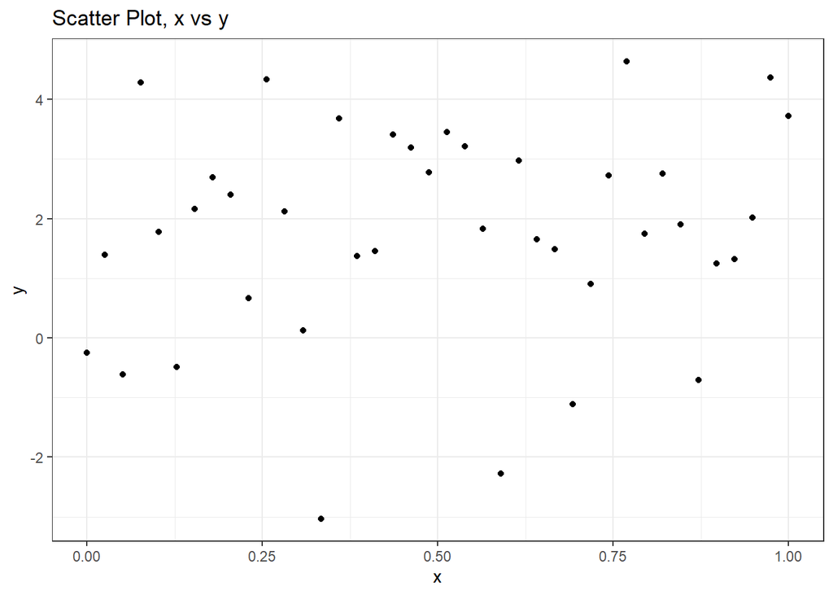

```r
x = seq(0,1,length = 40)
set.seed(1)
y = 1+1.2*x + rnorm(40,sd = 2)
ggplot()+
  geom_point(aes(x=x,y=y))+
  labs(title = "Scatter Plot, x vs y")+
  theme_bw()
```

## 4.2 Understand the model

```r
sim.reg.result = lm(y~x)
summary(sim.reg.result)
```

```
##
## Call:
## lm(formula = y ~ x)
##
## Residuals:
##    Min     1Q Median     3Q    Max
## -4.662 -0.880  0.014  1.247  2.882
##
## Coefficients:
##             Estimate Std. Error t value Pr(>|t|)
## (Intercept)    1.331      0.557    2.39    0.022 *
## x              0.906      0.959    0.95    0.350
## ---
## Signif. codes:  0 '***' 0.001 '**' 0.01 '*' 0.05 '.' 0.1 ' ' 1
##
## Residual standard error: 1.79 on 38 degrees of freedom
## Multiple R-squared:  0.023,  Adjusted R-squared:  -0.00272
## F-statistic: 0.894 on 1 and 38 DF,  p-value: 0.35
```

The true values for $\beta_0$ and $\beta_1$ are 1 and 1.2, respectively, while the estimates are 1.33 and 0.91, respectively. The estimates are not very accurate.

```r
round(confint(sim.reg.result,level = 0.95),digits = 2)
```

```
##             2.5 % 97.5 %
## (Intercept)  0.20   2.46
## x           -1.03   2.85
```

The 95% confidence interval for $\beta_1$ is [-1.03, 2.85]. It captures the true $\beta_1$.

**Comparison of the true model and the estimate**

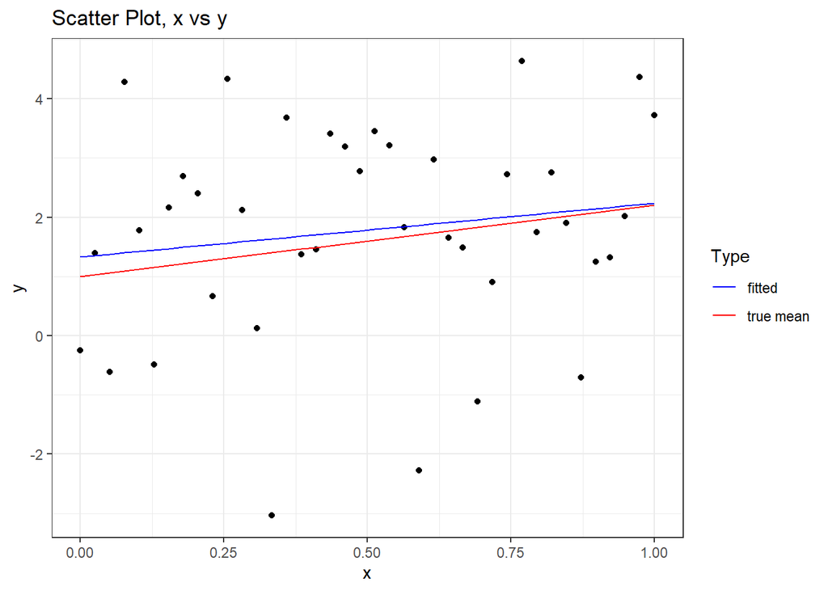

```r
ggplot(data.frame(x,y,fitted = sim.reg.result$fitted.values,truemean = 1+1.2*x))+
  geom_point(aes(x=x,y=y))+
  labs(title = "Scatter Plot, x vs y")+
  geom_line(aes(x=x,y=fitted,color="fitted"))+
  geom_line(aes(x=x,y=truemean,color="true mean"))+
  scale_color_manual(name="Type",values = c(`fitted`="blue",`true mean`="red"))+
  theme_bw()
```

## 4.3 Diagnoses

**Residual plot**

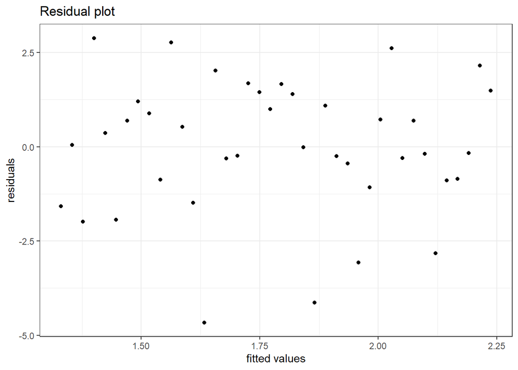

```r
ggplot()+
  geom_point(aes(x=sim.reg.result$fitted.values,y=sim.reg.result$residuals))+
  xlab("fitted values")+
  ylab("residuals")+
  labs(title = "Residual plot")+
  theme_bw()
```

**QQ plot**

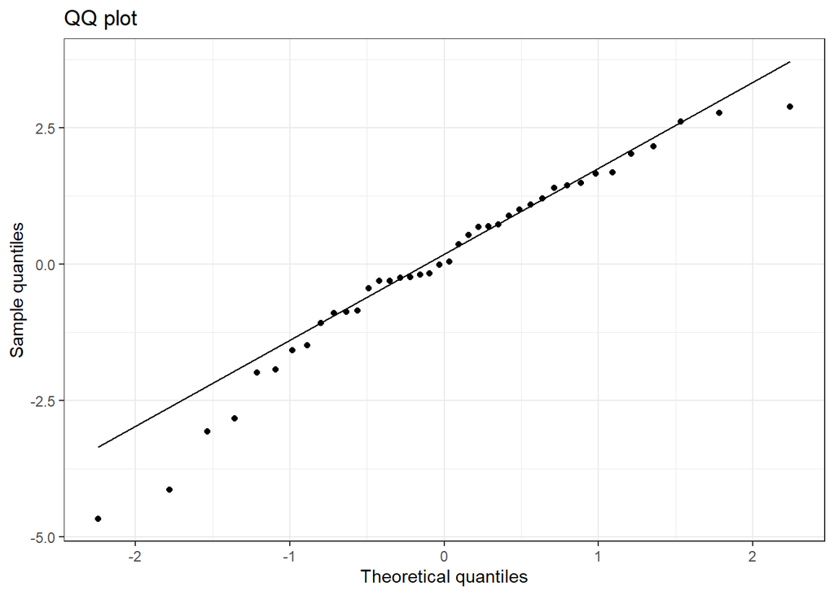

```r
ggplot()+
  geom_qq(aes(sample=sim.reg.result$residuals))+
  geom_qq_line(aes(sample=sim.reg.result$residuals))+
  xlab("Theoretical quantiles")+
  ylab("Sample quantiles")+
  labs(title = "QQ plot")+
  theme_bw()
```

**Comments**

The sample residuals seem to be uncorrelated with the fitted values, but they have thicker tails than the normal distribution when x is small, but thinner tails when x is big. This should be the result of randomization.

## 4.4 New simulation

```r
y.matrix = matrix(nrow = 40,ncol = 100)
result.matrix = data.frame(matrix(nrow = 100,ncol = 4))
colnames(result.matrix) = c("se","beta1","lower","upper")
t_star = qt(0.975,38)
for (i in 1:ncol(y.matrix)) {
  set.seed(i)
  y.matrix[,i] = 1+1.2*x+rnorm(40,sd=2)
  result.coef = summary(lm(y.matrix[,i]~x))$coefficients

  result.matrix[i,] = c(result.coef[2,2],result.coef[2,1],result.coef[2,1]-result.coef[2,2]*t_star,result.coef[2,1]+result.coef[2,2]*t_star)
}

skim(result.matrix$beta1)
```

Data summary

| Name | result.matrix$beta1 |
| --- | --- |
| Number of rows | 100 |
| Number of columns | 1 |
| _______________________ |  |
| Column type frequency: |  |
| numeric | 1 |
| ________________________ |  |
| Group variables | None |

**Variable type: numeric**

| skim_variable | n_missing | complete_rate | mean | sd | p0 | p25 | p50 | p75 | p100 | hist |
| --- | --- | --- | --- | --- | --- | --- | --- | --- | --- | --- |
| data | 0 | 1 | 1.13 | 1.09 | -1.65 | 0.38 | 1.09 | 1.99 | 3.56 | ▁▅▇▇▂ |

```r
theory.mean = 1.2
theory.sd = 2/sqrt((var(x)*39))

comparison.table = data.frame(mean = c(mean(result.matrix$beta1),theory.mean),sd = c(sd(result.matrix$beta1),theory.sd))
rownames(comparison.table) = c("bootstraping","theory")

kbl(comparison.table, caption = "Comparison between the simulated result (n=100) and the theory result", digits = 2, booktabs = T,
    align = "lcc") %>%
  kable_styling(latex_options = c("HOLD_position"))
```

Comparison between the simulated result (n=100) and the theory result

|  | mean | sd |
| --- | --- | --- |
| bootstraping | 1.13 | 1.09 |
| theory | 1.20 | 1.07 |

The sampling distribution is closed to the theoretical distribution, judging from the mean and standard deviation. However, there is still mild difference.

**Illustration of confidence interval**

```r
result.matrix = result.matrix %>%
  mutate(number = 1:100,real.mean = rep(1.2,100))
result.matrix = result.matrix %>%
  mutate(captured = real.mean>=lower & real.mean <= upper)
sum(result.matrix$captured)
```

```
## [1] 94
```

94% confidence intervals capture the true beta, which is close to the prediction of the significance, 95%.

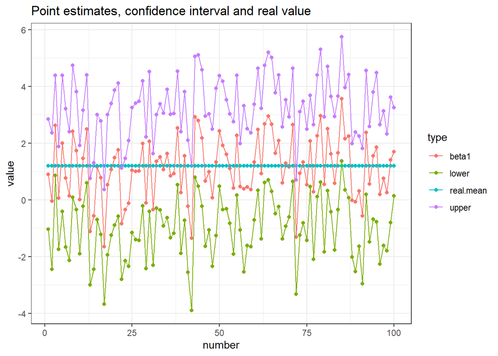

```r
result.matrix.long = result.matrix %>%
  pivot_longer(c(beta1,lower,upper,real.mean),names_to = "type")


ggplot(data = result.matrix.long,aes(x=number,y=value,group=type,color=type))+
  geom_point()+
  geom_line()+
  labs(title = "Point estimates, confidence interval and real value")+
  theme_bw()
```